# malbacR: A Vignette Pertaining to Pre-Filtered Data

Damon Leach, Kelly Stratton, Lisa Bramer

2023-03-23

The R package `malbacR` is a new package that deals with batch correction methods of small molecule omics data. It works in conjunction with `pmartR`, an R package designed for preprocessing, filtering, and analyzing multi-omics data (Stratton et al. 2019; Degnan et al. 2023).

This outline demonstrates the functionality and use of the `malbacR` package. Within this package, there are four data sets: `pmart_amide`, `pmart_amideFilt`,`pmart_mix`, and `pmart_mixFilt`. The first two objects contain data originally found in the package `WaveICA2.0` (Deng and Li 2022). The second two objects contain data originally found in the package `crmn` (Redestig et al. 2009). The data sets with the suffix “Filt” are filtered versions of the original data sets. That is, unlike their non-filtered counterparts, these data objects require no additional data manipulation for batch correction to successfully run. For this example, we work with the filtered data sets to demonstrate how the `malbacR` functions work.

Within `malbacR` there are 11 batch correction methods:

1. Range Scaling (Berg et al. 2006)
2. Power Scaling (Berg et al. 2006)
3. Pareto Scaling (Berg et al. 2006)
4. ComBat (Müller et al. 2016)
5. EigenMS (Karpievitch et al. 2014)
6. NOMIS (Sysi-Aho et al. 2007)
7. RUV-random (De Livera et al. 2015)
8. QC-RLSC (Dunn et al. 2011)
9. WaveICA2.0 (Deng et al. 2019)
10. TIGER (Han et al. 2022)
11. SERRF (Fan et al. 2019)

```r
library(malbacR)
library(pmartR)
library(ggplot2)
```

## Data Set 1: Amide Data

### Load in the Data

A `pmartR` friendly version of the “Amide” data that has already undergone filtering and log2 transformations is already implemented within `malbacR`. Therefore, we simply load in the data.

```r
data(pmart_amideFilt)
```

### Run Batch Correction Methods

It is important to note that the data `pmart_amideFilt` has been filtered, transformed, and imputed such that the data runs with all possible methods, but it may be conservative for a given method. For example, some methods do not require imputation to run, but because some methods require imputation (like SERRF and WaveICA2.0) (Fan et al. 2019; Deng et al. 2019), the data has been imputed.

```r
# SCALING METHODS
# range scaling
amide_range <- bc_range(omicsData = pmart_amideFilt)

# power scaling
amide_power <- bc_power(omicsData = pmart_amideFilt)

# pareto scaling
amide_pareto <- bc_pareto(omicsData = pmart_amideFilt)

# QUALITY CONTROL METHODS
# TIGER
amide_tiger <- bc_tiger(omicsData = pmart_amideFilt,sampletype_cname = "group",
                        test_val = "QC",injection_cname = "Injection_order")

# QC-RLSC
amide_qcrlsc <- bc_qcrlsc(omicsData = pmart_amideFilt,block_cname = "batch",
                          qc_cname = "group", qc_val = "QC", order_cname = "Injection_order",
                          missing_thresh = 0.5, rsd_thresh = 0.3, backtransform  = FALSE)

# SERRF
amide_serrf <- bc_serrf(omicsData = pmart_amideFilt,sampletype_cname = "group",test_val = "QC")

# OTHER METHODS
# ComBat
amide_combat <- bc_combat(omicsData = pmart_amideFilt, use_groups = FALSE)

# EigenMS
amide_eigen <- bc_eigenMS(omicsData = pmart_amideFilt)

# WaveICA2.0
amide_wave <- bc_waveica(omicsData = pmart_amideFilt, injection_cname = "Injection_order",
                         alpha = 0, cutoff = 0.1, K = 10)
```

### Data Visualization

After obtaining all the different batch corrected data sets, we can plot the PPCA to see if they are successfully returning batch corrected data. We set the `group_designation` to use our batch information as the `main_effects` so as to color the data by batch. All of this code is run using functions from `pmartR` demonstrating the utility between the two packages.

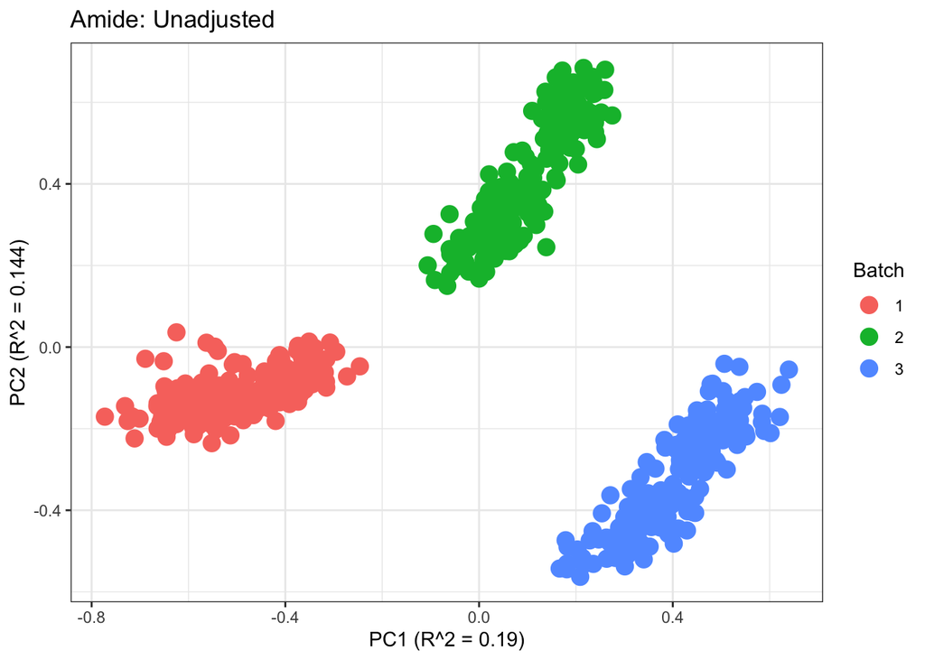

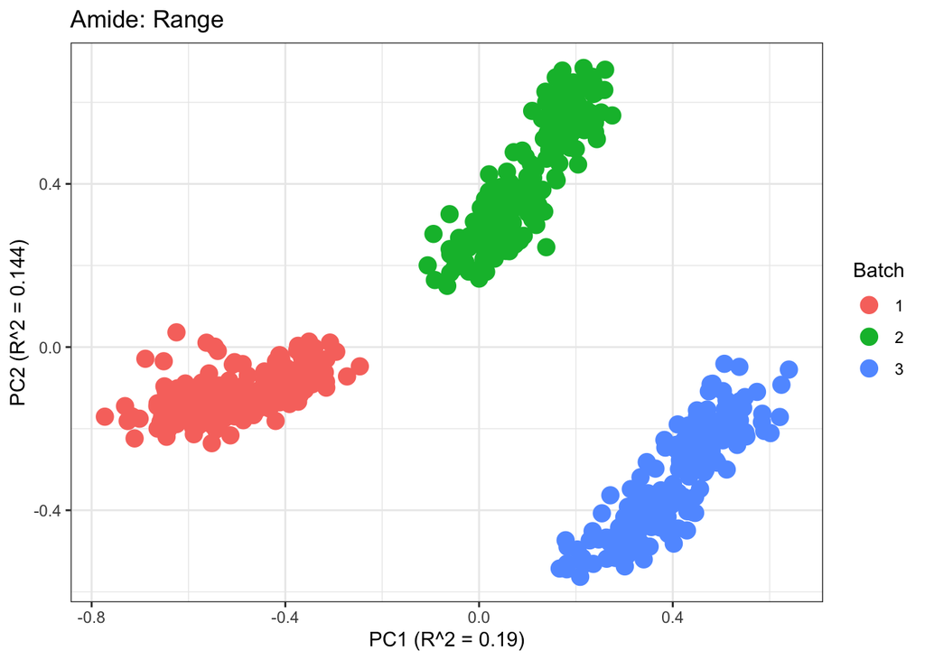

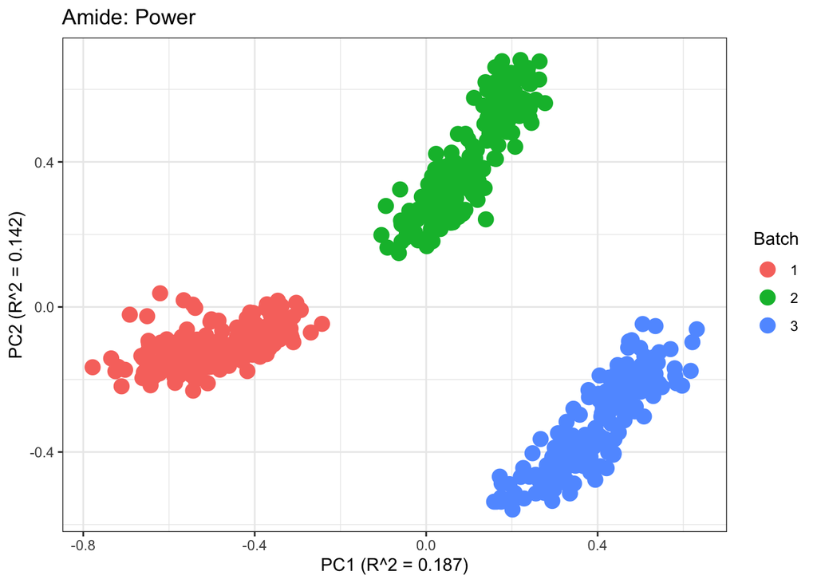

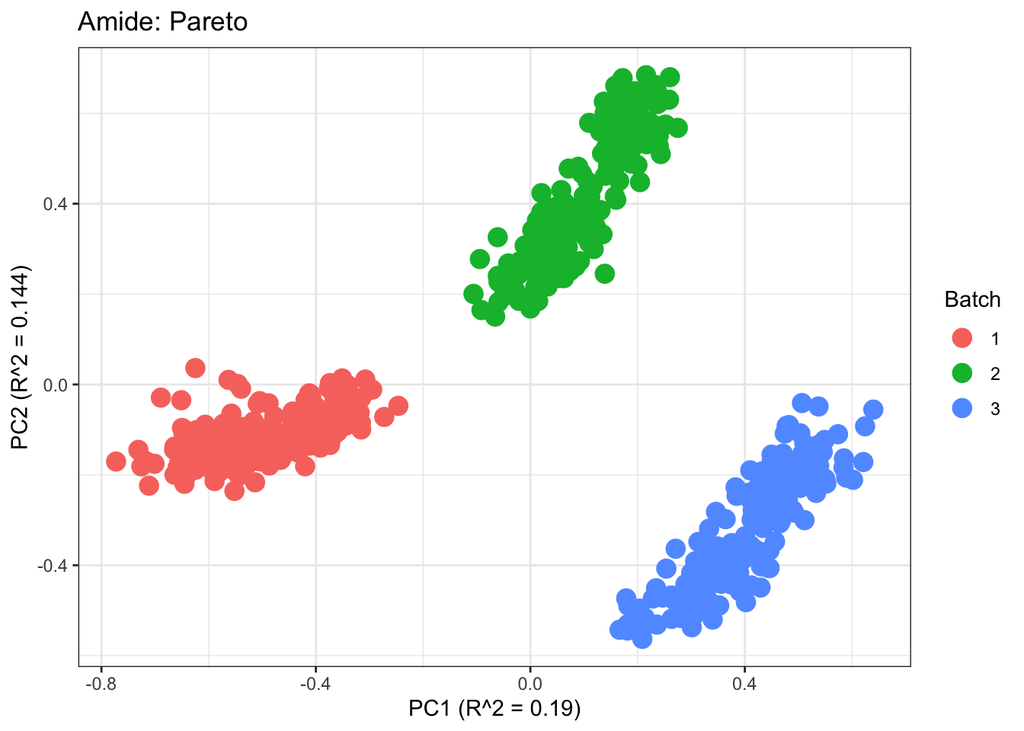

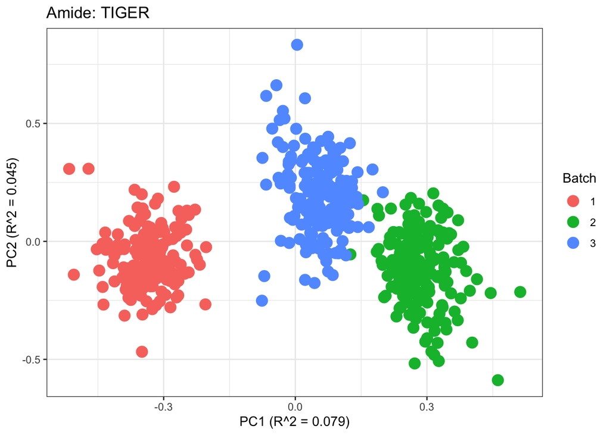

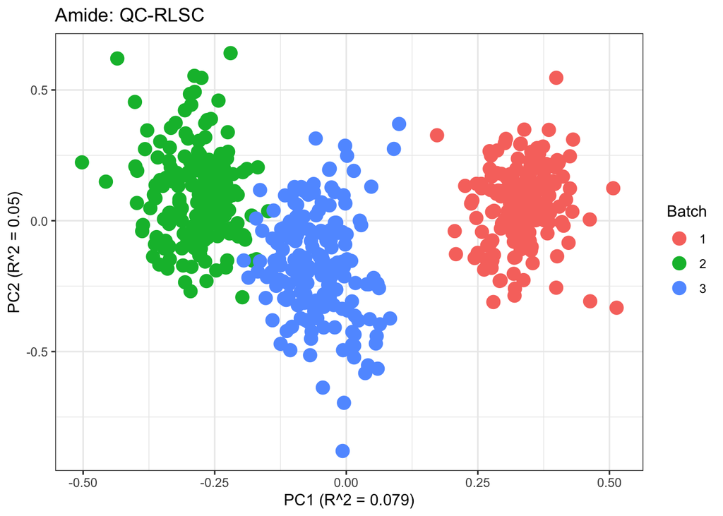

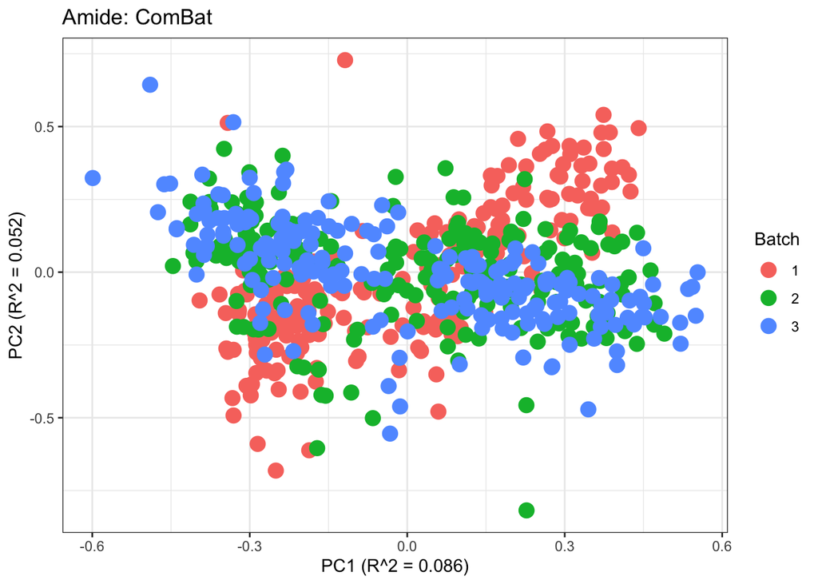

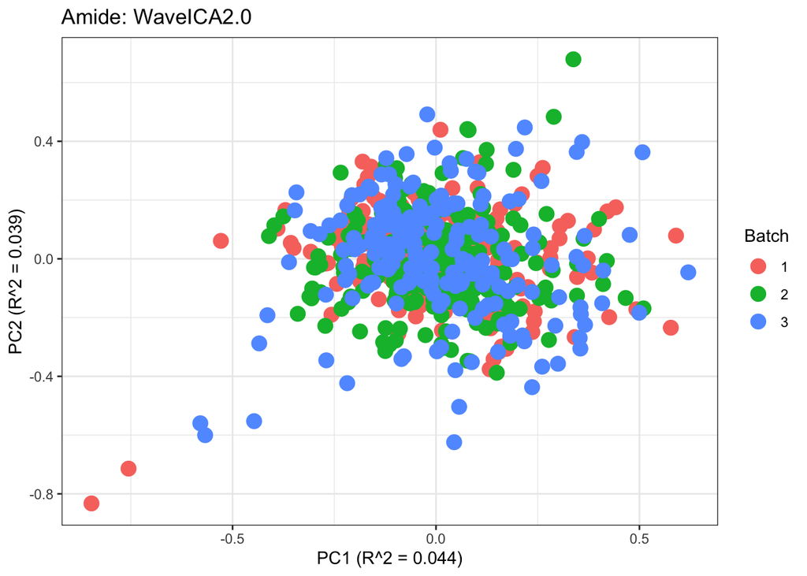

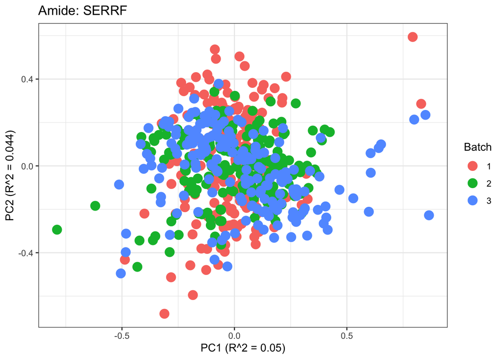

```r
pmart_amide <- group_designation(pmart_amideFilt,main_effects = "batch")
amide_range <- group_designation(amide_range,main_effects = "batch")
amide_power <- group_designation(amide_power,main_effects = "batch")
amide_pareto <- group_designation(amide_pareto,main_effects = "batch")
amide_tiger <- group_designation(amide_tiger,main_effects = "batch")
amide_qcrlsc <- group_designation(amide_qcrlsc,main_effects = "batch")
amide_combat <- group_designation(amide_combat,main_effects = "batch")
amide_wave <- group_designation(amide_wave,main_effects = "batch")
amide_serrf <- group_designation(amide_serrf,main_effects = "batch")

p1 <- plot(dim_reduction(omicsData = pmart_amide))+ scale_colour_discrete(name="Batch") + labs(title = "Amide: Unadjusted")
p2 <- plot(dim_reduction(omicsData = amide_range))+ scale_colour_discrete(name="Batch") + labs(title = "Amide: Range")
p3 <- plot(dim_reduction(omicsData = amide_power))+ scale_colour_discrete(name="Batch") + labs(title = "Amide: Power")
p4 <- plot(dim_reduction(omicsData = amide_pareto))+ scale_colour_discrete(name="Batch") + labs(title = "Amide: Pareto")
p5 <- plot(dim_reduction(omicsData = amide_tiger))+ scale_colour_discrete(name="Batch") + labs(title = "Amide: TIGER")
p6 <- plot(dim_reduction(omicsData = amide_qcrlsc))+ scale_colour_discrete(name="Batch") + labs(title = "Amide: QC-RLSC")
p7 <- plot(dim_reduction(omicsData = amide_combat))+ scale_colour_discrete(name="Batch") + labs(title = "Amide: ComBat")
p8 <- plot(dim_reduction(omicsData = amide_wave))+ scale_colour_discrete(name="Batch") + labs(title = "Amide: WaveICA2.0")
p9 <- plot(dim_reduction(omicsData = amide_serrf))+ scale_colour_discrete(name="Batch") + labs(title = "Amide: SERRF")

p1;p2;p3;p4;p5;p6;p7;p8;p9
```

## Data Set 2: Mix Data

### Load in the Data

The `malbacR` package includes another `pmartR` friendly data set for the “mix” data which has already undergone filtering and log2 transformations is already implemented within `malbacR`. Therefore, we simply load in the data.

```r
data(pmart_mixFilt)
```

### Run Batch Correction Methods

The “mix” data set contains information regarding negative controls/internal standards. Therefore the following methods can be used:

- Range Scaling
- Power Scaling
- Pareto Scaling
- RUV-random
- NOMIS
- ComBat

As there is no information regarding QC samples or injection order, the other batch correction methods in the package or not able to be used with this data set.

As with the `pmart_amideFilt` data set, is important to note that the data in `pmart_mixFilt` has been filtered and transformed such that the data runs with all possible methods, but it may be conservative for a given method. As there were no missing data with the “mix” data set, no imputation was computed.

```r
# SCALING METHODS
# range scaling
mix_range <- bc_range(omicsData = pmart_mixFilt)

# pareto scaling
mix_pareto <- bc_pareto(omicsData = pmart_mixFilt)

# power scaling
mix_power <- bc_power(omicsData = pmart_mixFilt)

# INTERNAL STANDARDS/NEGATIVE CONTROLS
# RUV-random
mix_ruv <- bc_ruvRandom(omicsData = pmart_mixFilt, nc_cname = "tag",nc_val = "IS", k = 3)

# NOMIS
mix_nomis <- bc_nomis(omicsData = pmart_mixFilt, is_cname = "tag", is_val = "IS", num_pc = 2)

# OTHER METHODS
mix_combat <- bc_combat(omicsData = pmart_mixFilt)
```

### Mix: Data Visualization

Similar to the previous data set, we can compare the PCA plots between the unadjusted and adjusted data sets.

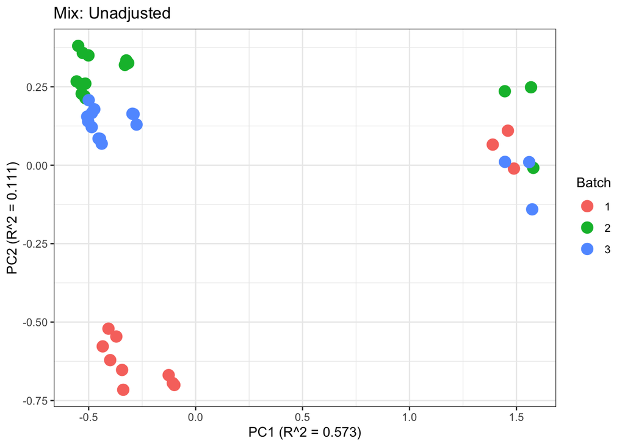

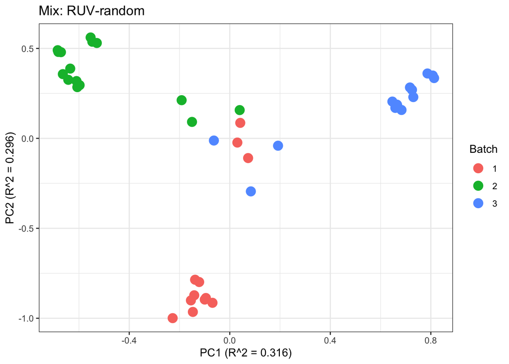

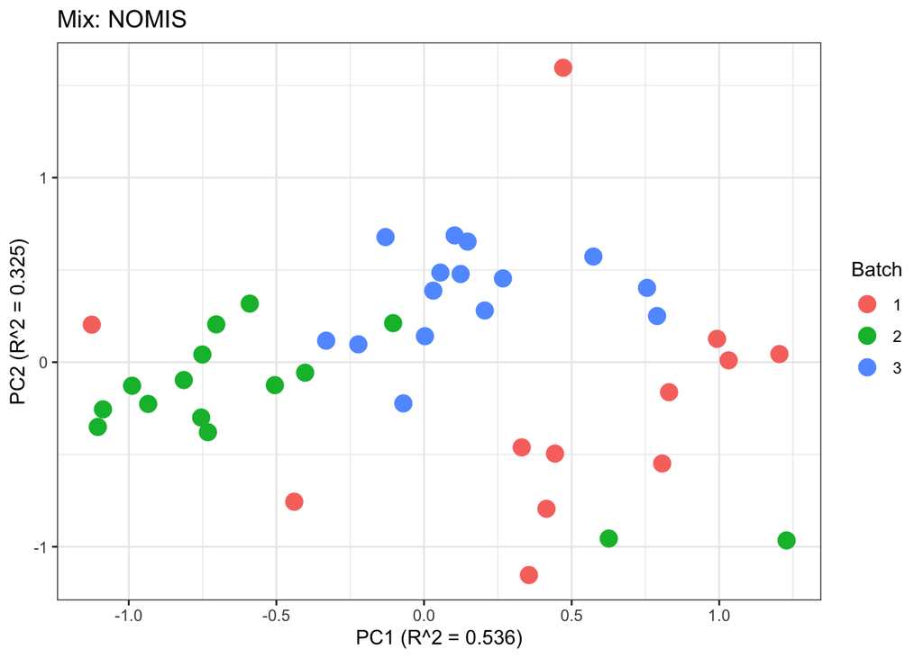

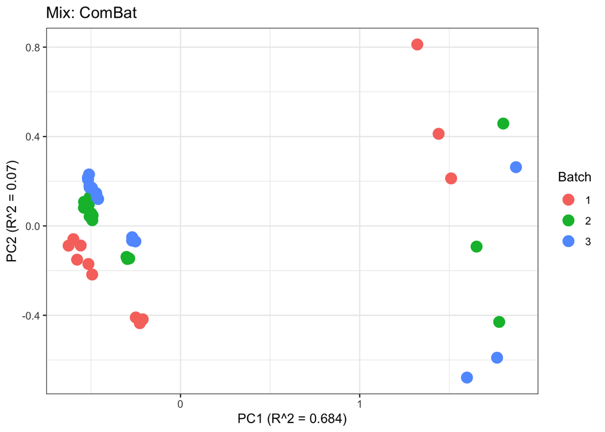

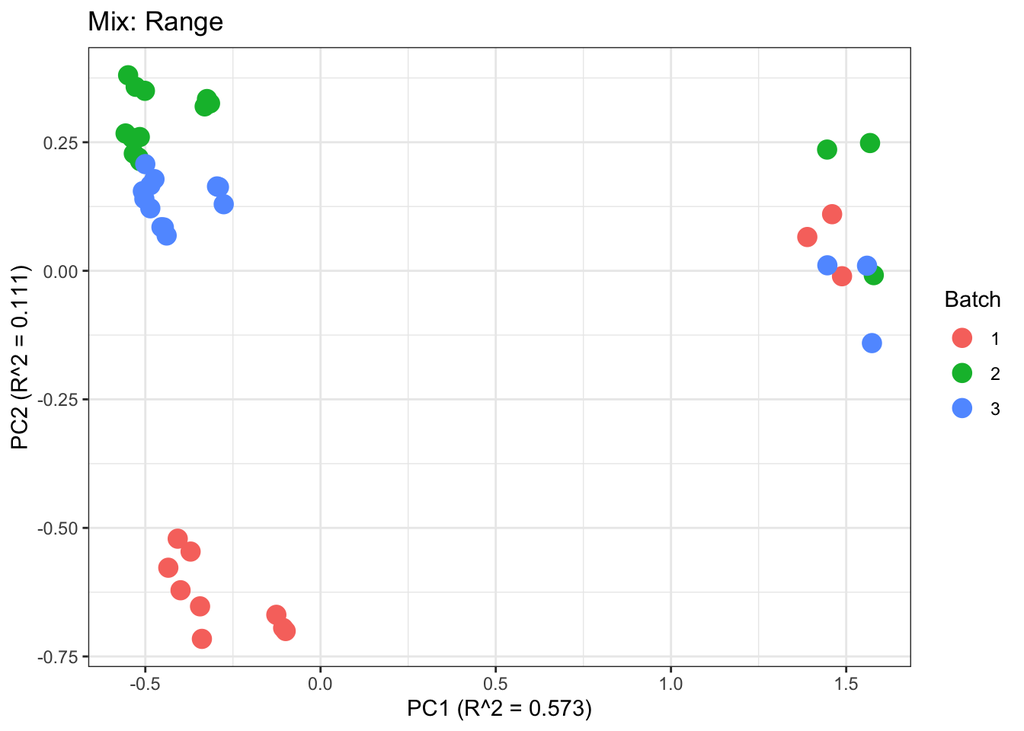

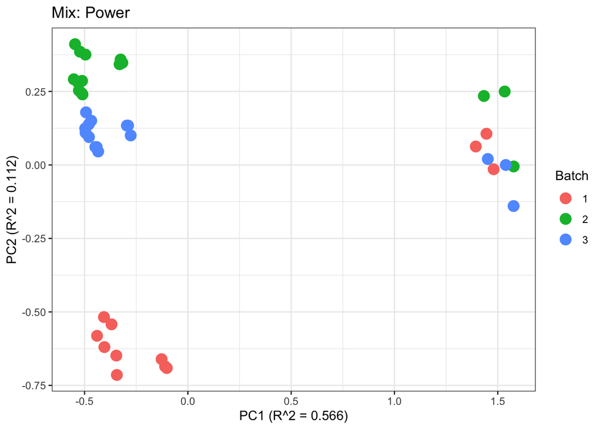

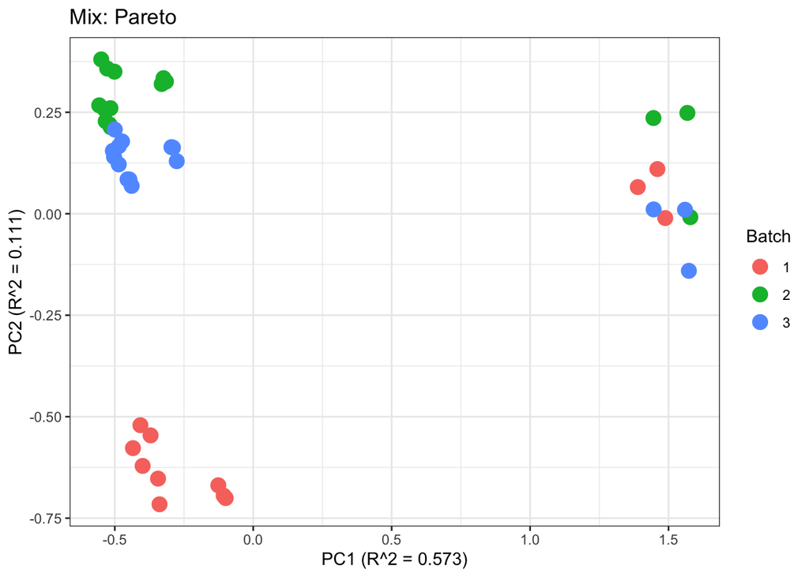

```r
pmart_mix <- group_designation(pmart_mixFilt,main_effects = "BatchNum")
mix_range <- group_designation(mix_range,main_effects = "BatchNum")
mix_power <- group_designation(mix_power,main_effects = "BatchNum")
mix_pareto <- group_designation(mix_pareto,main_effects = "BatchNum")
mix_combat <- group_designation(mix_combat,main_effects = "BatchNum")
mix_ruv <- group_designation(mix_ruv,main_effects = "BatchNum")
mix_nomis <- group_designation(mix_nomis,main_effects = "BatchNum")

p1 <- plot(dim_reduction(omicsData = pmart_mix)) + scale_colour_discrete(name="Batch") + labs(title = "Mix: Unadjusted")
p2 <- plot(dim_reduction(omicsData = mix_ruv)) + scale_colour_discrete(name="Batch") + labs(title = "Mix: RUV-random")
p3 <- plot(dim_reduction(omicsData = mix_nomis)) + scale_colour_discrete(name="Batch") + labs(title = "Mix: NOMIS")
p4 <- plot(dim_reduction(omicsData = mix_combat)) + scale_colour_discrete(name="Batch") + labs(title = "Mix: ComBat")
p5 <- plot(dim_reduction(omicsData = mix_range)) + scale_colour_discrete(name="Batch") + labs(title = "Mix: Range")
p6 <- plot(dim_reduction(omicsData = mix_power)) + scale_colour_discrete(name="Batch") + labs(title = "Mix: Power")
p7 <- plot(dim_reduction(omicsData = mix_pareto)) + scale_colour_discrete(name="Batch") + labs(title = "Mix: Pareto")

p1;p2;p3;p4;p5;p6;p7
```

## References

De Livera, Alysha M., Marko Sysi-Aho, Jacob Laurent, Johann A. Gagnon-Bartsch, Sandra Castillo, Julie A. Simpson, and Terence P. Speed. 2015. “Statistical Methods for Handling Unwanted Variation in Metabolomics Data.” *Analytical Chemistry* 87 (7): 3606–15. https://doi.org/10.1021/ac502439y.

Degnan, David J, Kelly G Stratton, Rachel Richardson, Daniel Claborne, Evan A Martin, Nathan A Johnson, Damon Leach, Bobbie-Jo M Webb-Robertson, and Lisa M Bramer. 2023. “pmartR 2.0: A Quality Control, Visualization, and Statistics Pipeline for Multiple Omics Datatypes.” *Journal of Proteome Research* 22 (2): 570–76. https://doi.org/10.1021/acs.jproteome.2c00610.

Deng, Kui, and Kang Li. 2022. *WaveICA2.0: WaveICA 2.0*.

Deng, Kui, Fan Zhang, Qilong Tan, Yue Huang, Zhiwei Rong, Zheng-Jiang Zhu, Kang Li, and Zhenzi Li. 2019. “WaveICA: A Novel Algorithm to Remove Batch Effects for Large-Scale Untargeted Metabolomics Data Based on Wavelet Analysis.” *Analytica Chimica Acta* 1061: 60–69. https://doi.org/10.1016/j.aca.2019.02.010.

Dunn, Warwick B., David Broadhurst, Paul Begley, Eva Zelena, Sue Francis-McIntyrre, Nadine Anderson, Marie Brown, et al. 2011. “Procedures for Large-Scale Metabolic Profiling of Serum and Plasma Using Gas Chromatography and Liquid Chromatography Coupled to Mass Spectrometry.” *Nature Protocols* 6 (7): 1060–83. https://doi.org/10.1038/nprot.2011.335.

Fan, Sili, Tobias Kind, Tomas Cajka, Stanley L. Hazen, H. W. Wilson Tang, Rima Kaddurah-Daouk, Marguerite R. Irvin, Donna K. Arnett, Dinesh K. Barupal, and Oliver Fiehn. 2019. “Systematic Error Removal Using Random Forest for Normalizing Large-Scale Untargeted Lipidomics Data.” *Analytical Chemistry* 91 (5): 3590–96. https://doi.org/10.1021/acs.analchem.8b05592.

Han, Siyu, Jialing Huang, Francesco Foppiano, Cornelia Prehn, Jerzy Adamski, Karsten Suhre, Ying Li, et al. 2022. “TIGER: Technical Variation Elimination for Metabolomics Data Using Ensemble Learning Architecture.” *Briefings in Bioinformatics* 23 (2). https://doi.org/10.1093/bib/bbab535.

Karpievitch, Yuliya V., Sonja B. Nikolic, Richard Wilson, James E. Sharman, and Lindsay M. Edwards. 2014. “Metabolomics Data Normalization with EigenMS.” *PLOS ONE* 9 (12). https://doi.org/10.1371/journal.pone.0116221.

Müller, Christian, Arne Schillert, Caroline Röthmeier, David-Alexandre Trégouët, Caroline Proust, Harald Binder, Norbert Pfeiffer, et al. 2016. “Removing Batch Effects from Longitudinal Gene Expression - Quantile Normalization Plus ComBat as Best Approach for Microarray Transcriptome Data.” *PLOS ONE* 11 (6). https://doi.org/10.1371/journal.pone.0156594.

Redestig, Henning, Atsushi Fukushima, Hans Stenlund, Thomas Moritz, Masanori Arita, Kazuki Saito, and Miyako Kusano. 2009. “Compensation for Systematic Cross-Contribution Improves Normalization of Mass Spectrometry Based Metabolomics Data.” *Analytical Chemistry* 81: 7974–80.

Stratton, Kelly G, Bobbie-Jo M Webb-Robertson, Lee Ann McCue, Daniel Claborne, Bryan Stanfill, Iobani Godinez, Thomas Johansen, et al. 2019. “pmartR: Quality Control and Statistics for Mass Spectrometry-Based Biological Data.” *Journal of Proteome Research*.

Sysi-Aho, Marko, Mikko Katajamaa, Laxman Yetukuri, and Matej Orešič. 2007. “Normalization Method for Metabolomics Data Using Optimal Selection of Multiple Internal Standards.” *BMC Bioinformatics* 8: 93. https://doi.org/10.1186/1471-2105-8-93.